# London Bike Sharing

Tsun Kin Chow (tkchow2@illinois.edu), Khuong Le (kmle2@illinois.edu), Shengjia Guo(sg17@illinois.edu), Shiyong Liu (shiyong2@illinois.edu)

16 December, 2019

# Abstract

> Statistical learning methods were applied to bike sharing data in order identify which is a good time for sharing bikes. There will be many factors that affect this problem. A variety of learning techniques were explored and validated. Simple methods like linear regression, k-nearest neighbors, tree decision model show promises, but further data collection and and complex training method is recommended.

# Introduction

Nowadays, there are many ways to share transportation, we can list out apps, like Lime and Bird, that allows user to rent a bicycle or scooters as long as they want. After you used the “transportations” you can leave it anywhere and other people will be able to find it on an application such that they can use it. We do an analysis base on TfL’s free transport data service data[^1] to look at the bike that is being shared in a certain amount of time.

The classification of number of bikes sharing is essential for business to identify which is a good time to release large number of bikes to the markets, such that it can handle large amount of useage, and to decide time to get back those bikes, since there will be time that no many users going to use bikes. The prediction of the number of bikes is also crucial for customers so that customers can imagine which is a good time to leave their bikes, cars at home and choose to share a bike for their convenience. A number of features is given in this dataset such that it can provide useful information to both the customers and bike sharing companies.

Statistical learning techniques were used to perform regression, multiclass classification, and classification number of bike sharing. We will splitted the project into two parts, first is regression part, where we will apply these models: random forest model, linear regression model, ridge regression model, lasso regression model, k-nearest neighbors model, decision tree model, support vector machine with linear kernel, neural network model. Secondly, we apply those methods to classification part. Since this is a relatively big data, we splitted the data into 4 seasons and each member in the group will do analysis on one of the seasons, and then report the RMSE, accuracy and test RMSE of each model. As a result, we will decide the best model after analysis on those 4 seasons and apply on the whole dataset.

## Methods

For the analysis, first we will split the dataset into 4 different seasons Spring, Summer, Fall, Winter and their code for the season is 0, 1, 2, 3 perspectively. For each of the season, we will try to train different methods, different models. Then we will choose the best one in each season and do a final analysis on the whole dataset.

The following two tasks will be performed using the london bike dataset:

- Regression
- Multiclass classification.

We spited each dataset into a training set and a test set and different statistical learning models were implemented on the training set to make both regression and classification on the cnt variable. The models were cross-validated and the parameters were tuned during the training phase. Then, cross-validated RMSEs were used to choose the best regression model and the cross-validated accuracies were used to choose the best classification model. The chosen models were then fitted to the whole training set and the performance of the models were validated by the test set.

## Data

This dataset is collected from Kaggle[^2] containing bike rent information in London from 2015 to 2016. We downloaded the file and name it as `london_merged.csv`. This dataset contains 10 variables and 17414 observations. We’re trying to predict the variable cnt, which stands for the count of bike share at a given time. Also, it might be useless for a person to know the exact amount of bikes rented at a specific time but instead a brief idea of the density of people using shared bikes so we also created a class variable indicating the density of people using shared bikes at a given time. The variable cnt is divided evenly into three groups: low, medium and high based on the 33rd percentile and 67th percentile of cnt in the whole dataset. Also, since R stores time data in a relatively vague way, we extracted the year, month, date and hour of the variable timestamp and forms new variables in order to make better predictions. The data is then spited based on seasons and statistical learning techniques are done to data within each season and the complete dataset as a whole.

## Modeling

### Variables Selection

First of all, we did some simple verification to determine the predictors. We plan to have three different set of predictors. Full models,

We will train models with full variables except timestamp as predictors and cnt as response. After that, we will train models with weather related variables such as `t1`, `t2`, `hum`, `wind_speed`, `weather_code`. Then, we train model base on time related variables `is_holiday`, `is_weekend`, `year`, `month`, `date`, `hour` model. We mainly have a look at some simple methods first.

- Linear Method
- KNN Method
- Tree Method

In order to correctly evaluate each model’s predicting power on number of shared bikes, we choose to split the data into estimation, validation and testing sets. The models are fit to estimation data and evaulated based on validation data. The metrics that will be used to determine each model’s performance will be their relative mean absolute error. The lower the rmse and mae value, the better the model perform at predicting the response variable.

| Methods | Full | Weather | Time |
| --- | --- | --- | --- |
| Linear Model | 552.47 | 935.04 | 1017.35 |
| KNN Model | 757.25 | 948.59 | 500.82 |
| Tree Model | 518.87 | 959.62 | 768.06 |

### Regression

In order to predict the bike count, 8 modeling techniques are considered: random forest, k-nearest neighbors, linear regression, ridge regression, lasso regression, decision trees, support vector machine, and neural network models.

- Random forest model: All predictors in the dataset are used for prediction. Out-of-bag error is used.
- Linear regression model: All predictors in the dataset are used for prediction.
- Ridge regression model: All predictors in the dataset are used for prediction. 5-fold cross-validation is performed.
- Lasso regression model: All predictors in the dataset are used for prediction. 5-fold cross-validation is performed.
- k-nearest neighbors model: All predictors in the dataset are used for prediction. 5-fold cross-validation is performed.
- Decision tree model: All predictors in the dataset are used for prediction. 5-fold cross-validation is performed.
- Support vector machine with linear kernel: All predictors in the dataset are used for prediction. 5-fold cross-validation is performed.
- Neural network model: All predictors in the dataset are used for prediction. 5-fold cross-validation is performed.

### Classification

- Random forest model: All predictors in the dataset are used for prediction. Out-of-bag error is used.
- k-nearest neighbors model: All predictors in the dataset are used for prediction. 5-fold cross-validation is performed.
- Decision tree model: All predictors in the dataset are used for prediction. 5-fold cross-validation is performed.
- Linear discriminant analysis model: All predictors in the dataset are used for prediction. 5-fold cross-validation is performed.
- Quadratic discriminant analysis model: All predictors in the dataset are used for prediction. 5-fold cross-validation is performed.
- Naive Bayes model: All predictors in the dataset are used for prediction. 5-fold cross-validation is performed.
- Multinomial logistic regression: All predictors in the dataset are used for prediction. 5-fold cross-validation is performed.
- Support vector machine model with linear kernel function: All predictors in the dataset are used for prediction. 5-fold cross-validation is performed.
- Neural network model: All predictors in the dataset are used for prediction. 5-fold cross-validation is performed.
- Gradient boosting model: All predictors in the dataset are used for prediction. 5-fold cross-validation is performed.

### Full Data

To select models that best predict the bike counts for the entire year, the regression models would be trained based on the full dataset. Using the full data, 8 regression models are considered: random forest, linear regression, ridge regression, lasso regression, decision trees, support vector machine, and neural network models.

## Evaluation

To evaluate the performance of regression models, the train RMSE and MAE for different regression models are reported in the results section. Models were tuned using out-of-bag error or 5-fold cross-validation to minimize the error in prediction. Based on the train datasets, the regression models would be evaluated using the train RMSE or OOB RMSE. The regression model with the lowest train RMSE or OOB RMSE might be chosen as the best regression model of bike counts.

To evaluate the performance of classification models, the train accuracy for different classification models are reported in the results section. Models were tuned using out-of-bag error or 5-fold cross-validation to maximize the accuracy in classification. Based on the train datasets, the classification models would be evaluated using the train accuracy or OOB accuracy. The classification model with the highest train accuracy or OOB accuracy might be chosen as the best model for classifying bike counts.

# Results

These are results from training methods above, it’s divided into regression, classification, and in each type we reported the value for models in Spring, Summer, Fall, Winter and even the Full dataset.

## Regression

### Spring

Spring - Models

Training Control

Best Tuning Parameter(s)

OOB RMSE

Train RMSE

OOB MAE

Train MAE

Random forest

Out-of-bag error

mtry = 2

839.77

598.42

Linear regression

874.38

653.44

Ridge regression

5-fold cross-validation

λ = 51.4014

858.02

634.03

Lasso regression

5-fold cross-validation

λ = 1.009

857.33

632.6

k-nearest neighbors

5-fold cross-validation

k = 19

837.33

611.86

Decision trees

5-fold cross-validation

cp = 0.0051

862.5

639.05

Support vector machine with linear kernel

5-fold cross-validation

C = 1

916.21

609.98

Neural Network

5-fold cross-validation

size = 1, decay = 0.0316

1524.86

1111.56

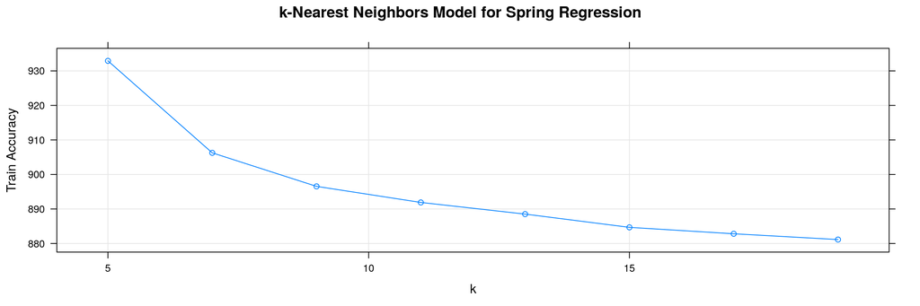

### Summer

Summer - Models

Training Control

Best Tuning Parameter(s)

OOB RMSE

Train RMSE

OOB MAE

Train MAE

Random forest

Out-of-bag error

mtry = 2

966.82

700.28

Linear regression

1014.89

769.7

Ridge regression

5-fold cross-validation

λ = 68.7493

985.69

736.04

Lasso regression

5-fold cross-validation

λ = 1.7841

985.17

734.26

k-nearest neighbors

5-fold cross-validation

k = 19

961.87

716.46

Decision trees

5-fold cross-validation

cp = 0.0054

1022.72

772.42

Support vector machine with linear kernel

5-fold cross-validation

C = 1

1059.8

723.14

Neural Network

5-fold cross-validation

size = 1, decay = 0.0316

1936.03

1471.83

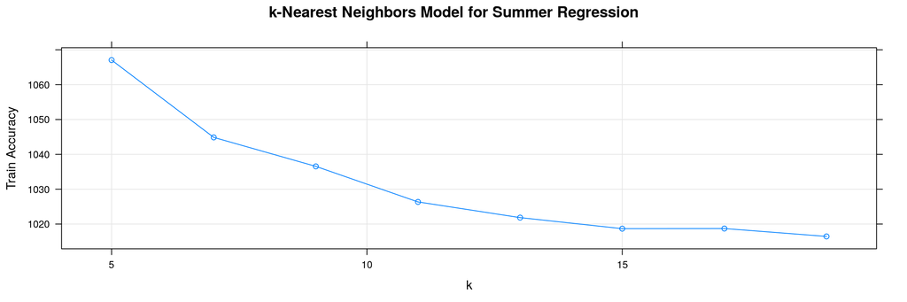

### Fall

Fall - Models

Training Control

Best Tuning Parameter(s)

OOB RMSE

Train RMSE

OOB MAE

Train MAE

Random forest

Out-of-bag error

mtry = 2

922.91

657.93

Linear regression

960.94

716.41

Ridge regression

5-fold cross-validation

λ = 44.5436

933.77

685.3

Lasso regression

5-fold cross-validation

λ = 0.8744

933.52

683.72

k-nearest neighbors

5-fold cross-validation

k = 19

919.92

676.87

Decision trees

5-fold cross-validation

cp = 0.0062

959.62

711.39

Support vector machine with linear kernel

5-fold cross-validation

C = 1

1003.4

666.62

Neural Network

5-fold cross-validation

size = 1, decay = 0.0316

1590.05

1169.88

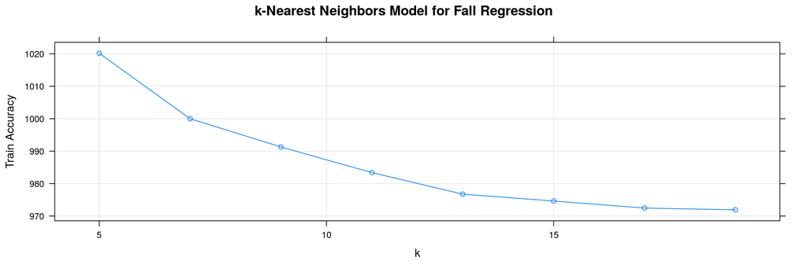

### Winter

Winter - Models

Training Control

Best Tuning Parameter(s)

OOB RMSE

Train RMSE

OOB MAE

Train MAE

Random forest

Out-of-bag error

mtry = 2

732.66

516.99

Linear regression

765.44

553.78

Ridge regression

5-fold cross-validation

λ = 21.3573

746.06

529.65

Lasso regression

5-fold cross-validation

λ = 0.1373

745.57

529.19

k-nearest neighbors

5-fold cross-validation

k = 17

733.43

523.14

Decision trees

5-fold cross-validation

cp = 0.0038

761.78

556.34

Support vector machine with linear kernel

5-fold cross-validation

C = 1

795.94

518.89

Neural Network

5-fold cross-validation

size = 1, decay = 0.0316

1161.04

828.82

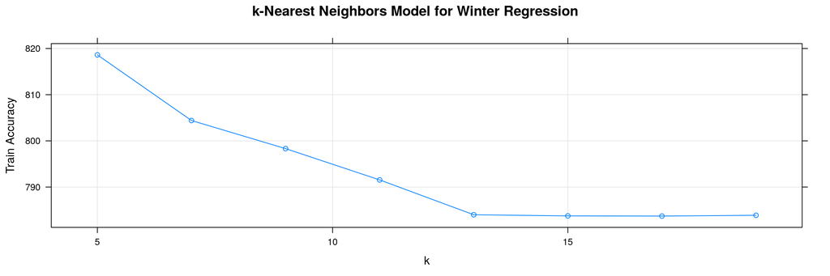

### Full Data

FULL - Models

Training Control

Best Tuning Parameter(s)

OOB RMSE

Train RMSE

OOB MAE

Train MAE

Random forest

Out-of-bag error

mtry = 2

885.02

634.74

Linear regression

931.49

691.09

Ridge regression

5-fold cross-validation

λ = 50.1965

906.99

663.14

Lasso regression

5-fold cross-validation

λ = 2.0741

906.57

661.87

k-nearest neighbors

5-fold cross-validation

k = 19

884.4

650.25

Decision trees

5-fold cross-validation

cp = 0.0055

934.19

691.18

Support vector machine with linear kernel

5-fold cross-validation

C = 1

969.79

649.42

Neural Network

5-fold cross-validation

size = 1, decay = 0.1

1576.64

1143.51

[figure not shown]

## Multiclass Classification

### Spring

Model

Training Control

Best Tuning Parameter(s)

OOB Accuracy

Train Accuracy

Random forest

Out-of-bag error

mtry = 2

0.4241

k-nearest neighbors

5-fold cross-validation

k = 13

0.6385

Decision trees

5-fold cross-validation

cp = 0.0035

0.5967

Linear discriminant analysis

5-fold cross-validation

0.5683

Quadratic discriminant analysis

5-fold cross-validation

0.5813

Naive Bayes

5-fold cross-validation

laplace = 0, usekernel = TRUE, adjust = 1

0.5739

Multinomial logistic regression

5-fold cross-validation

decay = 0.1

0.5634

Support vector machine with linear kernel

5-fold cross-validation

C = 1

0.5674

Neural network

5-fold cross-validation

size = 13, decay = 0.0003

0.5879

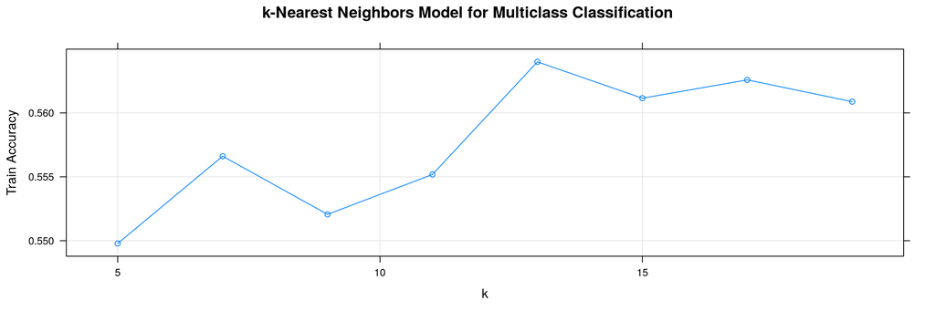

### Summer

Model

Training Control

Best Tuning Parameter(s)

OOB Accuracy

Train Accuracy

Random forest

Out-of-bag error

mtry = 2

0.3875

k-nearest neighbors

5-fold cross-validation

k = 13

0.6664

Decision trees

5-fold cross-validation

cp = 0.0032

0.6499

Linear discriminant analysis

5-fold cross-validation

0.6142

Quadratic discriminant analysis

5-fold cross-validation

0.5986

Naive Bayes

5-fold cross-validation

laplace = 0, usekernel = TRUE, adjust = 1

0.6228

Multinomial logistic regression

5-fold cross-validation

decay = 0.1

0.6177

Support vector machine with linear kernel

5-fold cross-validation

C = 1

0.6231

Neural network

5-fold cross-validation

size = 13, decay = 0.1

0.6436

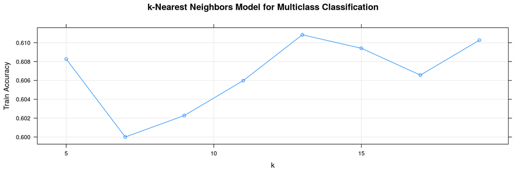

### Fall

Model

Training Control

Best Tuning Parameter(s)

OOB Accuracy

Train Accuracy

Random forest

Out-of-bag error

mtry = 2

0.3925

k-nearest neighbors

5-fold cross-validation

k = 13

0.6102

Decision trees

5-fold cross-validation

cp = 0.004

0.5577

Linear discriminant analysis

5-fold cross-validation

0.524

Quadratic discriminant analysis

5-fold cross-validation

0.5199

Naive Bayes

5-fold cross-validation

laplace = 0, usekernel = FALSE, adjust = 1

0.508

Multinomial logistic regression

5-fold cross-validation

decay = 0.0032

0.5213

Support vector machine with linear kernel

5-fold cross-validation

C = 1

0.5257

Neural network

5-fold cross-validation

size = 15, decay = 0.0316

0.5324

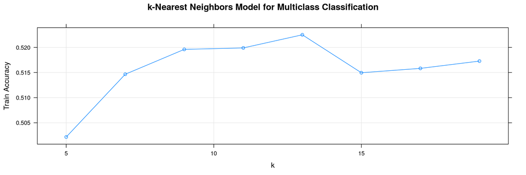

### Winter

Model

Training Control

Best Tuning Parameter(s)

OOB Accuracy

Train Accuracy

Random forest

Out-of-bag error

mtry = 2

0.5882

k-nearest neighbors

5-fold cross-validation

k = 19

0.5922

Decision trees

5-fold cross-validation

cp = 0.0032

0.5547

Linear discriminant analysis

5-fold cross-validation

0.5469

Quadratic discriminant analysis

5-fold cross-validation

0.4583

Naive Bayes

5-fold cross-validation

laplace = 0, usekernel = TRUE, adjust = 1

0.4843

Multinomial logistic regression

5-fold cross-validation

decay = 0.1

0.5452

Support vector machine with linear kernel

5-fold cross-validation

C = 1

0.542

Neural network

5-fold cross-validation

size = 13, decay = 0.0032

0.5541

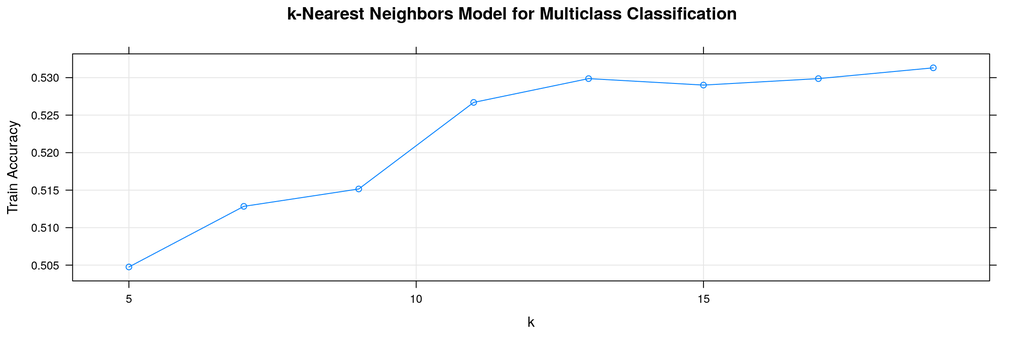

### Full Data

Model

Training Control

Best Tuning Parameter(s)

OOB Accuracy

Train Accuracy

Random forest

Out-of-bag error

mtry = 2

0.3506

k-nearest neighbors

5-fold cross-validation

k = 19

0.5544

Decision trees

5-fold cross-validation

cp = 0.0047

0.5201

Linear discriminant analysis

5-fold cross-validation

0.5025

Quadratic discriminant analysis

5-fold cross-validation

0.4903

Naive Bayes

5-fold cross-validation

laplace = 0, usekernel = TRUE, adjust = 1

0.5154

Multinomial logistic regression

5-fold cross-validation

decay = 0.0316

0.5056

Support vector machine with linear kernel

5-fold cross-validation

C = 1

0.5076

Neural network

5-fold cross-validation

size = 13, decay = 0.01

0.5201

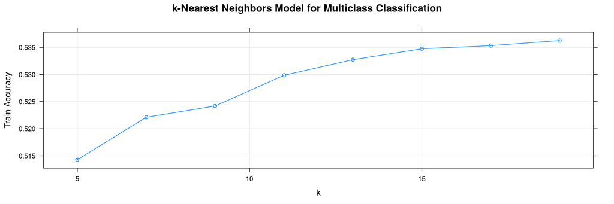

Regression:

Classification:

From the results above, surprisingly that same with the regression, all of the season sub-dataset and even including that the whole dataset works best on K-nearest neighbors. The accuracy for different models are close to close to each other. We can see that it has around 60% of accuracy. We think that although around 60% is not a really big number, but to correctly 60% of the 17414 is a big number.

# Discussion

Based on the full training dataset, the best regression model is the k-nearest neighbors model with k = 19 and the best classification model is the the k-nearest neighbors model with k = 19. We select the best regression model based on train RMSE and the best classification model based on train accuracy. In the following section, we would present the metrics of the performance of the best models based on the testing datasets. The performance of the best models would then be evaluated. Some limitations of the analysis would also discussed.

### Regression

I choose the k-nearest neighbors model with k = 19 as the best model for regression based on full dataset.

The metrics for my chosen best regression models based on the both full dataset and the datasets for the four seasons are given by:

| Data | Best Model | Best Tuning Parameter | Test RMSE |
| --- | --- | --- | --- |
| Full data | k-nearest neighbors | k = 19 | 891.9721 |
| Spring | k-nearest neighbors | k = 19 | 835.1213 |
| Summer | k-nearest neighbors | k = 19 | 951.9786 |
| Fall | k-nearest neighbors | k = 19 | 1052.1820 |
| Winter | k-nearest neighbors | k = 17 | 716.0811 |

### Classification

I choose the k-nearest neighbors model with k = 19 as the best model for classification based on full dataset.

The metrics for my chosen best regression models based on the both full dataset and the datasets for the four seasons are given by:

| Data | Best Model | Best Tuning Parameter | Test Accuracy |
| --- | --- | --- | --- |
| Full data | k-nearest neighbors | k = 19 | 60.4825 |
| Spring | k-nearest neighbors | k = 13 | 63.2118 |
| Summer | k-nearest neighbors | k = 13 | 66.7047 |
| Fall | k-nearest neighbors | k = 13 | 58.0233 |
| Winter | k-nearest neighbors | k = 19 | 58.3815 |

### Conclusion

All in all, based on RMSE and using the full data, the best regression model is the k-nearest neighbors model with k = 19. Based on accuracy and using the full data, the the best classification model is the the k-nearest neighbors model with k = 19. From the test results, the chosen regression model has a substantially lower test RMSE of 891.9721 and the chosen classification model has a relatively higher test accuracy of 60.4825. Nevertheless, our conclusion of the best regression and classification models might in fact be dependent on different model specifications, cross-validation methods, and types of data of the bike counts in London. More predictors, variables, or information about the use of bikes in London might be useful in prediction of bike counts. It is also possible that other regression and classification models might also be estimated that give different conclusions. Further discussion on the choice of models and the evaluation of statistical learning models might be needed in the foreseeable future.

# Appendix

## Data Dictionary

- `timestamp` - timestamp field for grouping the data
- `cnt` - the count of a new bike shares
- `t1` - real temperature in C
- `t2` - temperature in C “feels like”
- `hum` - humidity in percentage
- `wind_speed` - wind speed in km/h
- `weather_code` - category of the weather
- `is_holiday` - boolean field - 1 holiday / 0 non holiday
- `is_weekend` - boolean field - 1 if the day is weekend
- `season` - category field meteorological seasons: 0-spring ; 1-summer; 2-fall; 3-winter.

“weathe_code” category description:

- 1 = Clear ; mostly clear but have some values with haze/fog/patches of fog/ fog in vicinity
- 2 = scattered clouds / few clouds
- 3 = Broken clouds
- 4 = Cloudy
- 7 = Rain/ light Rain shower/ Light rain
- 10 = rain with thunderstorm
- 26 = snowfall
- 94 = Freezing Fog

For additional background on the data, see the data source.

[^1]: [London bike sharing dataset](https://www.kaggle.com/hmavrodiev/london-bike-sharing-dataset)
[^2]: [London bike sharing dataset](https://www.kaggle.com/hmavrodiev/london-bike-sharing-dataset)